# Walk-forward performance

S&P 500 network momentum · annual expanding WFO · 2019–2025

**Research proxy with 38 unavailable portfolio dates.** Equity and drawdown stop at each gap and restart at 100. A continuous seven-year equity curve and full-period maximum drawdown remain unavailable.

## Daily performance statistics

| strategy | Annualized mean* | Annualized vol* | Sharpe* | Sortino* | Positive days* | Worst 5% mean* | Worst day* | Best day* |
| --- | --- | --- | --- | --- | --- | --- | --- | --- |
| LongOnly | 6.79% | 8.65% | 0.786 | 1.091 | 54.70% | -1.30% | -3.50% | 3.15% |
| MACD | -0.66% | 3.11% | -0.213 | -0.281 | 52.56% | -0.51% | -1.31% | 1.06% |
| LinReg | 6.27% | 8.11% | 0.774 | 1.075 | 54.53% | -1.23% | -3.48% | 3.14% |
| GMOM | 6.03% | 7.97% | 0.757 | 1.051 | 54.53% | -1.21% | -3.50% | 3.14% |
| RegCombo | 5.90% | 7.82% | 0.755 | 1.049 | 54.30% | -1.19% | -3.49% | 3.12% |
| SignCombo | 6.15% | 8.03% | 0.767 | 1.065 | 54.41% | -1.22% | -3.49% | 3.14% |

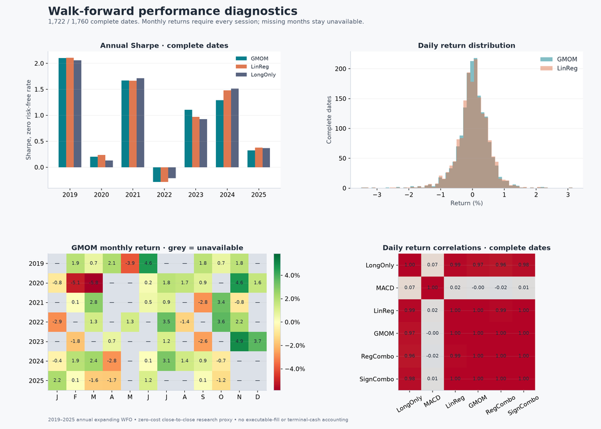

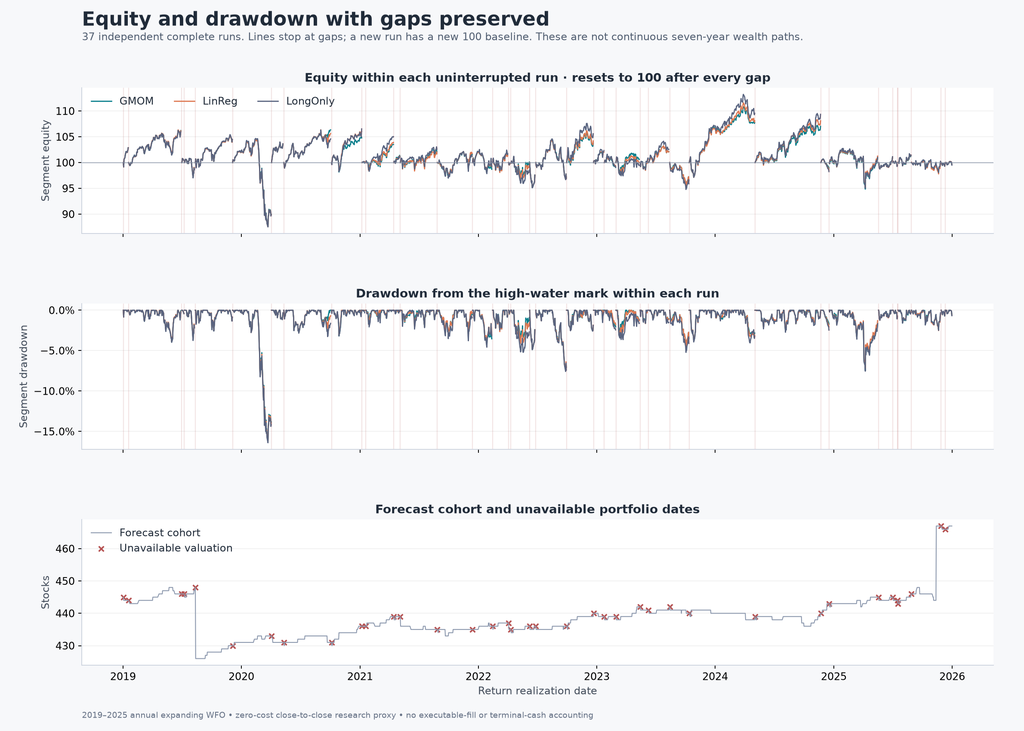

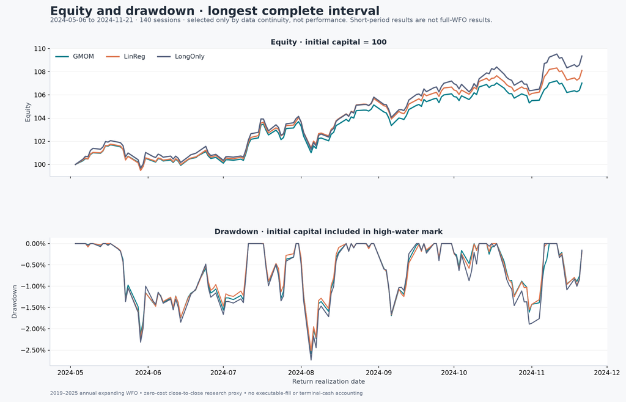

## Longest complete interval: 2024-05-06 to 2024-11-21

140 sessions, chosen by continuity only. This interval is a small part of the WFO.

| strategy | Interval return | Interval max drawdown | Positive days |
| --- | --- | --- | --- |
| LongOnly | 9.36% | -2.73% | 57.14% |
| MACD | 2.57% | -0.89% | 53.57% |
| LinReg | 8.12% | -2.52% | 57.14% |
| GMOM | 7.03% | -2.58% | 56.43% |
| RegCombo | 6.40% | -2.58% | 55.71% |
| SignCombo | 7.57% | -2.55% | 55.71% |

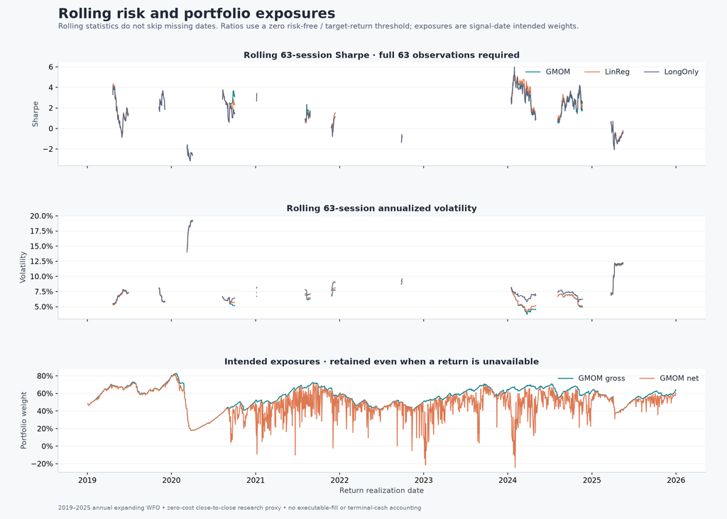

## Definitions and interpretation

- *Complete-date statistics describe 1,722 observed dates out of 1,760, conditional on availability. They are not a continuous seven-year performance record.
- The 38 incomplete dates and all forecasts remain saved. No missing return is filled or reweighted away. Equity and drawdown restart at each uninterrupted run; cross-gap CAGR, total return, maximum drawdown, Calmar and recovery duration remain withheld.
- Sortino = sqrt(252) × mean daily return / sqrt(mean(min(return, 0)²)); zero threshold. Sharpe uses sample daily volatility and zero risk-free rate. Annualized mean = 252 × daily arithmetic mean, not CAGR.
- Positive-day fraction includes zero-return days in its denominator. Worst 5% mean averages the worst ceil(0.05 × observed days) returns. These are portfolio-day statistics, not trade win rates or trade profit factors.
- Monthly compounded returns require every scheduled session to be observed. Rolling 63-session statistics require all 63 returns and stay unavailable across gaps. Intended exposures use all signal dates, including unavailable valuation dates.
- LongOnly is an inverse-volatility-sized matched cohort, not the capital-weighted S&P 500. Trading costs, financing, borrow, executable fills and complete terminal/corporate-action cash flows are not included.
- No models, hyperparameters, membership rules, prices or saved returns were changed for these diagnostics. No model selection uses these test results.